```r
library(tidyverse)
library(lubridate)
```

*2. Manchester United*

**a) Read in the file and display some of the resulting data frame.**

```r
my_url <- "http://ritsokiguess.site/STAD29/manu.csv"
manu <- read_csv(my_url)
manu
```

```
## # A tibble: 29 x 11
##    number name  nationality date_of_birth   age country_of_birth place_of_birth
##     <dbl> <chr> <chr>       <chr>         <dbl> <chr>            <chr>
##  1      1 Davi… Spain       7 November 1…    29 Spain            Madrid
##  2     13 Lee … England     27 January 1…    36 England          Hemel Hempste…
##  3     22 Serg… Argentina   22 February …    32 Argentina        Bernardo de I…
##  4      2 Vict… Sweden      17 July 1994     25 Sweden           Västerås
##  5      3 Eric… Côte d'Ivo… 12 April 1994    25 Côte d'Ivoire    Bingerville
##  6      4 Phil… England     21 February …    27 England          Preston
##  7      5 Harr… England     5 March 1993     26 England          Sheffield
##  8     16 Faus… Argentina   20 March 1990    29 Argentina        La Plata
##  9     18 Ashl… England     9 July 1985      34 England          Stevenage
## 10     20 José… Portugal    18 March 1999    20 Portugal         Braga
## # … with 19 more rows, and 4 more variables: position <chr>, height <chr>,
## #   weight <chr>, foot <chr>
```

**b) What kind of thing is the column date_of_birth? Create a new column that contains the players’ dates of birth as actual R dates, and display the old dates of birth alongside your new column (or at least the first few rows of them). Save your updated data frame.**

The date_of_birth column is in chr format. This means that they haven’t been read as Dates because they were not in year-month-day order.

```r
manu %>% mutate(birthdate = dmy(date_of_birth)) -> manu2
```

```r
manu2 %>% select(number, name, nationality, date_of_birth, birthdate, age, country_of_birth, place_of_birth, position, height, weight, foot)
```

```
## # A tibble: 29 x 12
##    number name  nationality date_of_birth birthdate    age country_of_birth
##     <dbl> <chr> <chr>       <chr>         <date>     <dbl> <chr>
##  1      1 Davi… Spain       7 November 1… 1990-11-07    29 Spain
##  2     13 Lee … England     27 January 1… 1983-01-27    36 England
##  3     22 Serg… Argentina   22 February … 1987-02-22    32 Argentina
##  4      2 Vict… Sweden      17 July 1994  1994-07-17    25 Sweden
##  5      3 Eric… Côte d'Ivo… 12 April 1994 1994-04-12    25 Côte d'Ivoire
##  6      4 Phil… England     21 February … 1992-02-21    27 England
##  7      5 Harr… England     5 March 1993  1993-03-05    26 England
##  8     16 Faus… Argentina   20 March 1990 1990-03-20    29 Argentina
##  9     18 Ashl… England     9 July 1985   1985-07-09    34 England
## 10     20 José… Portugal    18 March 1999 1999-03-18    20 Portugal
## # … with 19 more rows, and 5 more variables: place_of_birth <chr>,
## #   position <chr>, height <chr>, weight <chr>, foot <chr>
```

**c) Treating the new column of fates as quantitative, make a suitable plot of these with the players’ position on the field. What do you see on the quantitative axis?**

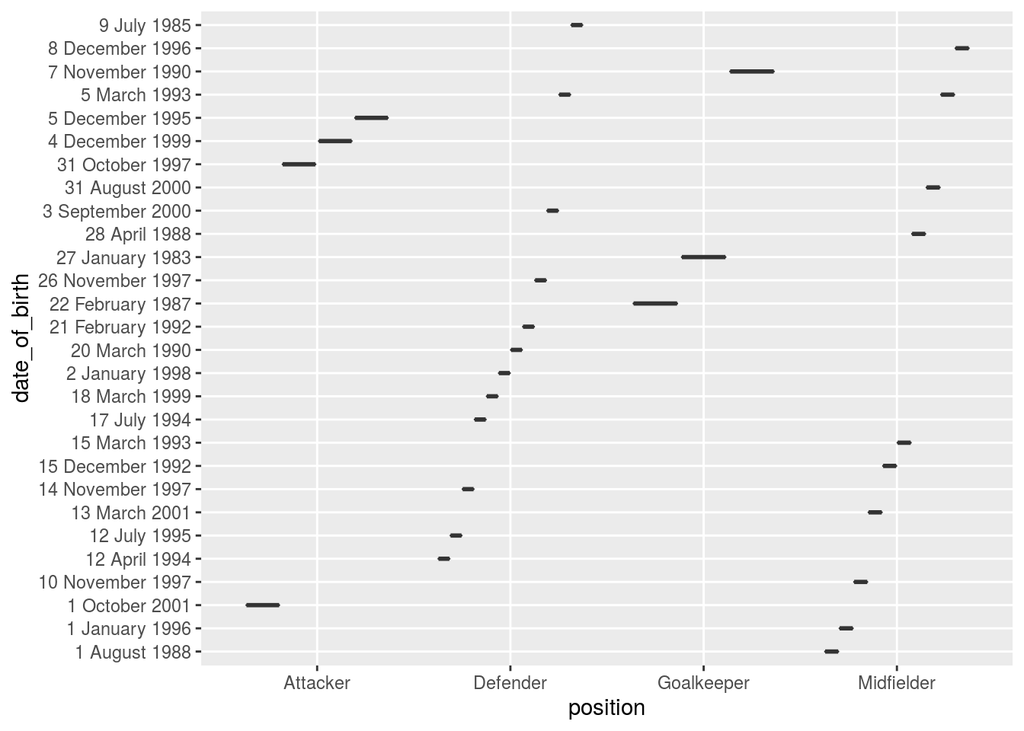

```r
ggplot(manu2, aes(x = position, y = date_of_birth)) + geom_boxplot()
```

**d) Is there a position where the players tend to be older?**

**e) Work out how many years old you are by using something like as.Date(“1966-04-13”) to turn your birth date into an R date, create a period from the interval from it to know (use Sys.Date() to get today’s date), and pull out the number of (completed) years.**

```r
Sys.Date()
```

```
## [1] "2020-01-15"
```

```r
as.Date("1999-05-13")
```

```
## [1] "1999-05-13"
```

```r
mydates <- c("1999-05-13")
(somedates <- tibble(birthday = mydates) %>%
mutate(
birthday = as.Date("1999-05-13"),
birth = as.Date(birthday),
today = Sys.Date(),
age = as.period(birthday %--% today),
age = year(age)
))
```

```
## # A tibble: 1 x 4
##   birthday   birth      today        age
##   <date>     <date>     <date>     <int>
## 1 1999-05-13 1999-05-13 2020-01-15    20
```

**f) Go back to the Manchester United players. Calculate a new column containing the age, in completed years, of each player as measured today. Display your new column side by side with the one called age.**

```r
manu2 %>%
  mutate(
    birthday = as.period(birthdate %--% Sys.Date()),
    howold = year(birthday)
  ) -> manu3
```

```r
manu3 %>% select(age, howold)
```

```
## # A tibble: 29 x 2
##      age howold
##    <dbl>  <int>
##  1    29     29
##  2    36     36
##  3    32     32
##  4    25     25
##  5    25     25
##  6    27     27
##  7    26     26
##  8    29     29
##  9    34     34
## 10    20     20
## # … with 19 more rows
```

**g) Display the names and (original) birth dates of the players whose age (in the original data frame) and whose age (as you calculated it) are different. What do these players have in common?**

```r
manu3 %>% filter(age != howold) %>%
  select(age, howold, date_of_birth)
```

```
## # A tibble: 3 x 3
##     age howold date_of_birth
##   <dbl>  <int> <chr>
## 1    21     22 2 January 1998
## 2    26     27 15 December 1992
## 3    23     24 1 January 1996
```

These players have in common that their birthday is towards the end/start of the new year (birthdays in December or January). The reason why the age that was calculated before doesn’t match up with the newly calculated dates is because the data was collected at the beginning of December, meaning that these players birthdays have passed but have not been updated in the data.

*4. Pitcher*

**a) Read in the (space-delimited) data and confirm that you have the right number of rows and the right columns (the column sos contains the number of strikeouts).**

```r
url <- "http://ritsokiguess.site/STAD29/pitchers.txt"
pitchers <- read_delim(url, " ")
pitchers
```

```
## # A tibble: 40 x 2
##     wins   sos
##    <dbl> <dbl>
##  1    21   248
##  2    12   158
##  3    19   220
##  4    13   191
##  5    17   238
##  6    16   158
##  7    24   250
##  8     8   134
##  9    18   198
## 10    10   197
## # … with 30 more rows
```

I have 2 columns and 40 rows for the 40 pitchers.

**b) Fit a linear regression (predicting wins from strikeouts), and display the output.**

```r
pitchers.1 <- lm(wins ~ sos, data = pitchers)
summary(pitchers.1)
```

```
##
## Call:
## lm(formula = wins ~ sos, data = pitchers)
##
## Residuals:
##     Min      1Q  Median      3Q     Max
## -5.4479 -1.9829 -0.0056  2.1047  5.8755
##
## Coefficients:
##             Estimate Std. Error t value Pr(>|t|)
## (Intercept)  3.98386    2.13331   1.867   0.0696 .
## sos          0.05656    0.01158   4.885  1.9e-05 ***
## ---
## Signif. codes:  0 '***' 0.001 '**' 0.01 '*' 0.05 '.' 0.1 ' ' 1
##
## Residual standard error: 2.814 on 38 degrees of freedom
## Multiple R-squared:  0.3857, Adjusted R-squared:  0.3695
## F-statistic: 23.86 on 1 and 38 DF,  p-value: 1.903e-05
```

**c) Obtain a confidence interval for the mean number of wins for pitchers that have 125 and 175 stikeouts, based on your regression of the previous part.**

```r
sos <- c(125, 175)
sos.new <- tibble(strikeout = sos)
sos.new
```

```
## # A tibble: 2 x 1
##   strikeout
##       <dbl>
## 1       125
## 2       175
```

```r
pc <- predict(pitchers.1, sos.new, interval = "c")
pp <- predict(pitchers.1, sos.new, interval = "p")
```

```r
cbind(sos.new, pc)
```

```
##   strikeout      fit       lwr      upr
## 1       125 11.05417  9.478053 12.63028
## 2       175 13.88229 12.973493 14.79108
```

**d) Which one of your intervals in the previous part is longer? Explain briefly how that makes sense.**

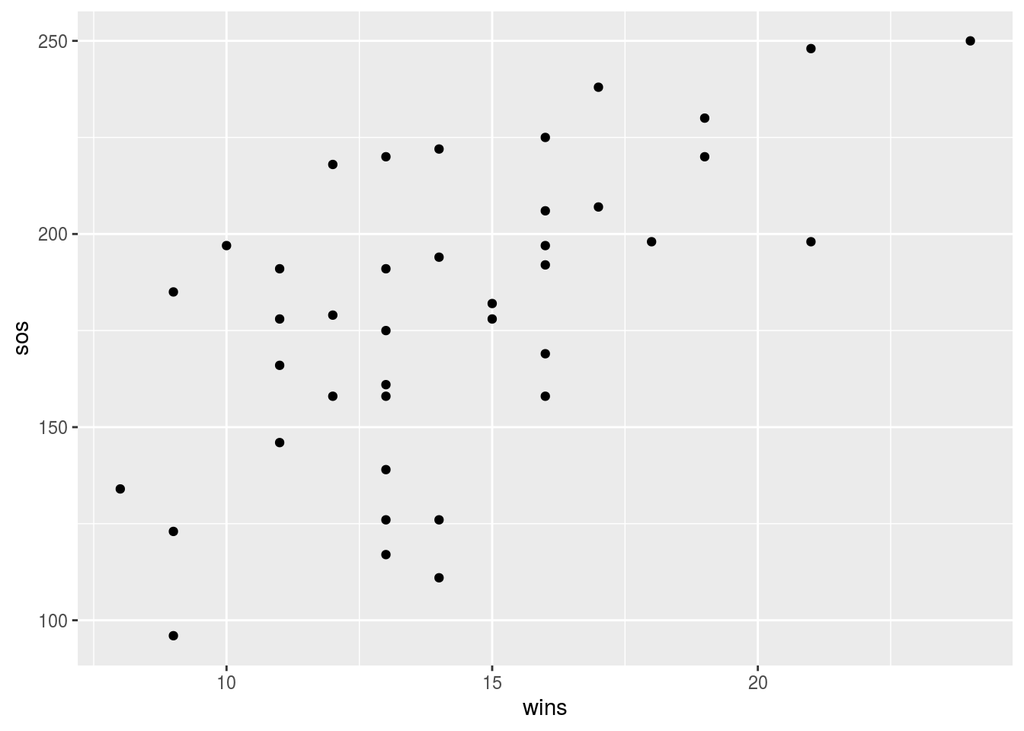

```r
ggplot(pitchers, aes(x = wins, y = sos)) + geom_point()
```

The interval for 125 strikeouts is longer. This makes sense because the relationship is not as strong as the one for 175 strikeouts. The more strikeouts the pitcher has the better as it increases their chance at winning the game and vice versa. That means with less strikeouts, like 125, it means that there is less of a chance that the pitcher winning making the chances of winning uncertain.

Also, there are more points around the 175 strikeouts than around 125 strikeouts. Because there are more points around 175 the interval is shorter.

**e) Find the prediction intervals for the number of wins for new pitchers (ones not in this data set) who have 125 and 175 strikeouts.**

```r
cbind(sos.new, pp)
```

```
##   strikeout      fit      lwr      upr
## 1       125 11.05417 5.143849 16.96448
## 2       175 13.88229 8.113960 19.65062
```